# IPL Complete Dataset (2008-2020)

# 3)Most appeared Umpires

When we plot the bar chart we can clearly see that S Ravi has appeared in most of the matches and he can also be called the most senior umpire and most experienced umpire.

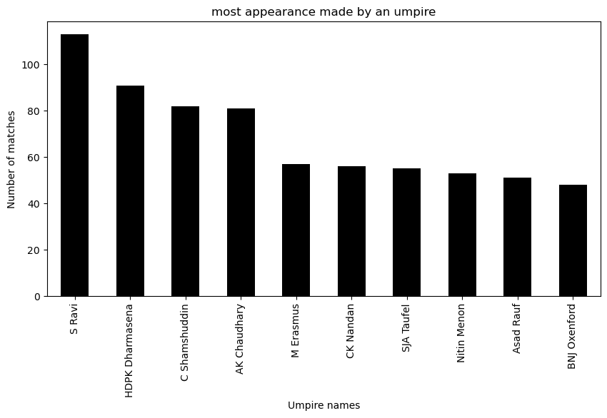

```python
Most_appeared_umpires = pd.concat([df['umpire1'], df['umpire2']]).value_counts()
most_appearance_by_umpires = Most_appeared_umpires.head(10)


plt.figure(figsize=(10,5))

#Plotting Bar Chart
most_appearance_by_umpires.plot(kind = 'bar', color = 'black')
plt.title("most appearance made by an umpire")
plt.xlabel('Umpire names')
plt.ylabel('Number of matches')
plt.plot()
plt.show()
```

# 4)Toss Analysis

Here in toss analysis, from the bar graph we can see what impact does toss has on the match outcome. The X-Axis contains the Toss result and Y-Axis contains percentage of matches won. We can see from the bar graph that winning the toss has slight edge on winning the match as teams which have won the toss have won more matches than the teams which have lost the toss. Also, if we see the stacked bar chart, we can see what different team’s decision is after they win the toss. The X-Axis has the team winning the toss and Y-Axis has the number of matches. We can see from the graph that Kolkata Knight Riders and Royal Challengers Bangalore are the teams which choose to field if they win the toss rather than to take bat first. Chennai Super Kings, Deccan Chargers and Pune Warriors are the only teams that prefer to bat after winning the toss compared to other teams.

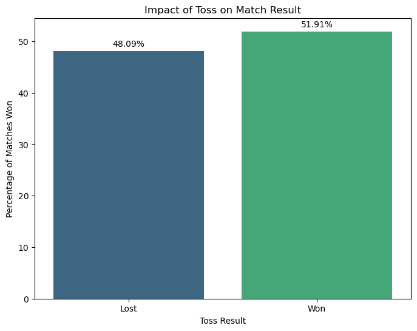

```python
df['toss_winner_won'] = df['toss_winner'] == df['winner']

#https://stackoverflow.com/questions/23627782/pandas-groupby-size-and-percentages
toss_impact = df.groupby('toss_winner_won').size() / len(df) * 100

plt.figure(figsize=(8, 6))

#plotting Seaborn Barchart
sns.barplot(x=toss_impact.index, y=toss_impact.values, palette='viridis')
plt.title("Impact of Toss on Match Result")
plt.xlabel('Toss Result')
plt.ylabel('Percentage of Matches Won')
plt.xticks([0, 1], ['Lost', 'Won'], rotation=0)

#https://stackoverflow.com/questions/67112449/bar-labels-in-matplotlib-seaborn
for index, value in enumerate(toss_impact.values):
    plt.text(index, value + 0.5, f'{value:.2f}%', ha='center', va='bottom')

plt.show()
```

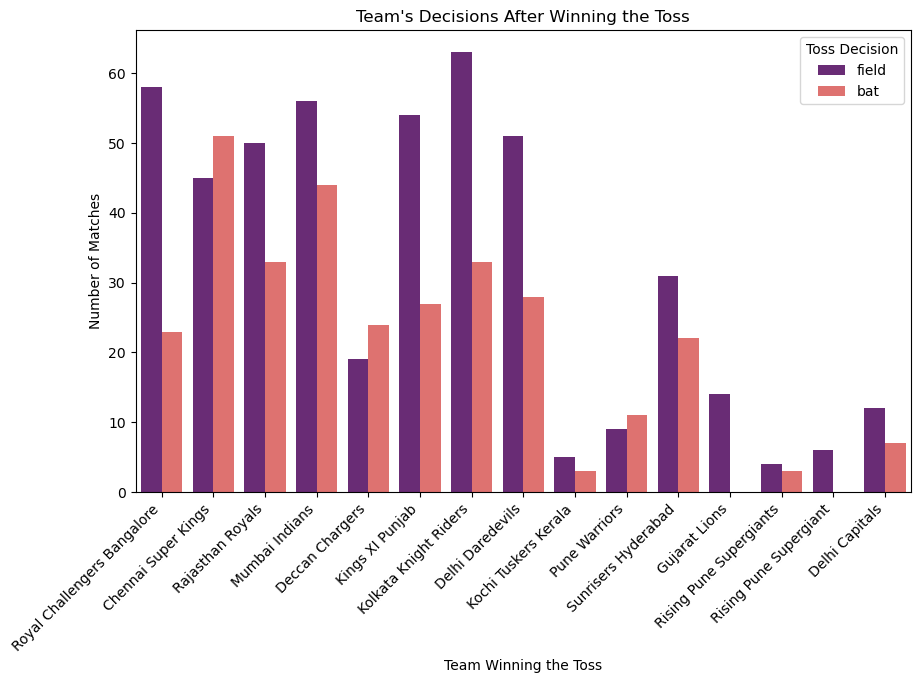

```python
plt.figure(figsize=(10, 6))
sns.countplot(x='toss_winner', hue='toss_decision', data=df, palette='magma')
plt.title("Team's Decisions After Winning the Toss")
plt.xlabel('Team Winning the Toss')
plt.ylabel('Number of Matches')
plt.xticks(rotation=45, ha='right')
plt.legend(title='Toss Decision', loc='upper right')

plt.show()
```

# 5)Date Analysis

# 5.1)Matches played in yearly basis from 2008-2020

Here we can see how many matches have been played in each year from 2008-2020. For this first we need to convert the date column to date time format. Then we extract the year from the date column. Then the count of matches played every year is found by using the value_counts() and it is sorted in ascending order from 2008-2020 by using sort.index(). Once this is done, we can plot a line plot using seaborn library, the X-Axis will contain year and Y-Axis will contain Number of Matches. From the line plot we can clearly see the number of matches played each year. The most number of matches is played in 2012 and 2013 with 74 matches and the least matches is played in 2014 with only 46.

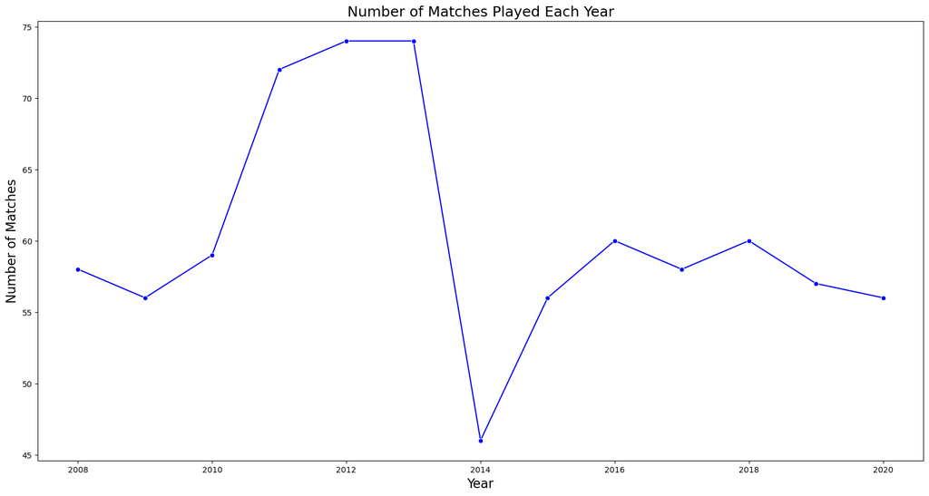

```python
df['date'] = pd.to_datetime(df['date'])


df['year'] = df['date'].dt.year


matches_played_every_year = df['year'].value_counts().sort_index()



plt.figure(figsize=(20, 10))

#LinePlot
#https://seaborn.pydata.org/generated/seaborn.lineplot.html
sns.lineplot(x=matches_played_every_year.index, y=matches_played_every_year.values, marker='o', color='blue')

plt.title("Number of Matches Played Each Year", fontsize=18)
plt.xlabel('Year', fontsize=16)
plt.ylabel('Number of Matches', fontsize=16)

plt.show()
```

# 5.2) Distribution of Matches Across Months

Here like yearly analysis, the months are extracted from the date column and count of matches played every month is found and it is reordered by using reindex () since the month names were not in order. We are plotting a seaborn bar chart using seaborn library, the X-Axis will contain Month and Y-Axis will contain Number of matches. From the bar chart we can clearly see that the number of matches played is very high for April and May and we can hardly see a few matches which is played in the month of June, September, and November.

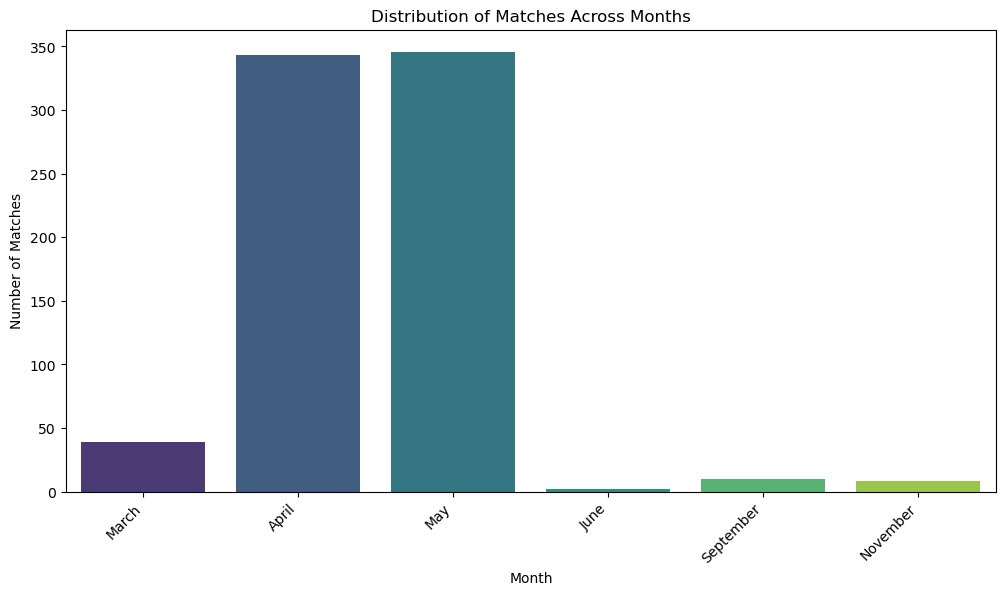

```python
df['date'] = pd.to_datetime(df['date'])
df['month'] = df['date'].dt.month_name()
matches_per_month = df['month'].value_counts().sort_index()
matches_per_month = df['month'].value_counts().reindex(['March', 'April', 'May', 'June', 'September','November'])

plt.figure(figsize=(12, 6))

#plotting Barchart
sns.barplot(x=matches_per_month.index, y=matches_per_month.values, palette='viridis')
plt.title("Distribution of Matches Across Months")
plt.xlabel('Month')
plt.ylabel('Number of Matches')
plt.xticks(rotation=45, ha='right')

plt.show()
```

# 5.3) Distribution of Matches Across Days of the Week

Here like Distribution of Matches Across months. The days of the week are sorted in order from Monday to Sunday. A bar chart is plotted using seaborn library. The X-Axis will contain Day of the week and Y-Axis will contain Number of Matches. It is no surprise that the number of matches played peaks during the weekend (Saturday and Sunday) and Monday has relatively a less number of matches played compared to other days of the week.

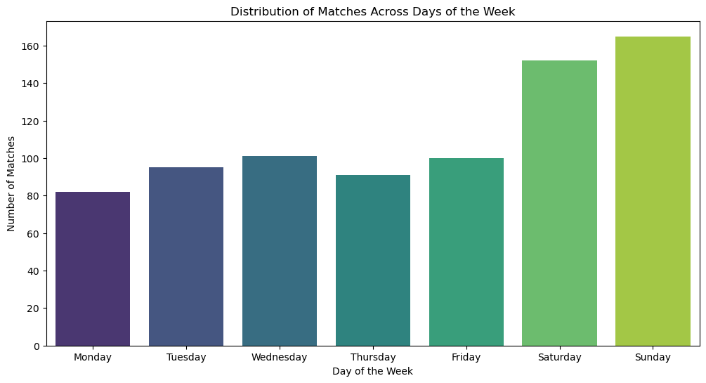

```python
df['day_of_week'] = df['date'].dt.day_name()

matches_per_day_of_week = df['day_of_week'].value_counts().reindex(['Monday', 'Tuesday', 'Wednesday', 'Thursday', 'Friday', 'Saturday', 'Sunday'])

plt.figure(figsize=(12, 6))
sns.barplot(x=matches_per_day_of_week.index, y=matches_per_day_of_week.values, palette='viridis')
plt.title("Distribution of Matches Across Days of the Week")
plt.xlabel('Day of the Week')
plt.ylabel('Number of Matches')

plt.show()
```

# 6) Margin of Victory

Here we can see that the result column is taken and by using value count (), we can see different ways in which the win has occurred. Here it is of 2 types. Winning by Wickets and winning by runs. We can clearly see in the bar graph that winning by wickets is more compared to winning by runs. The X-Axis has Result type which in turn has wickets and runs and Y-Axis has Number of matches.

```
result
wickets    427
runs       359
Name: count, dtype: int64
```

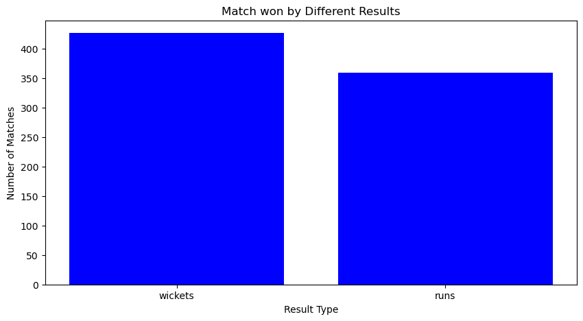

```python
Different_match_results = df['result'].value_counts()
print(Different_match_results)

plt.figure(figsize = (10,5))
plt.bar(Different_match_results.index, Different_match_results.values, color = 'blue')
plt.title('Match won by Different Results')
plt.xlabel('Result Type')
plt.ylabel('Number of Matches')
plt.show()
```

Here for this graph the result column is checked for wickets, wherever it matches with the wickets in that column it will take those values. Similarly, for runs also it checks for runs in that column, wherever it matches with the runs in that column it will take those values. Here we are using subplots to show matches won by wickets and runs beside each other. When we see the matches won by wickets it peaks at 6 wicket margins, it is also high for 5 and 7 as well. The matches won by runs are very close matches as we can see that more matches have been won with the runs from 0 to 40. Both the graphs are plotted using a histogram.

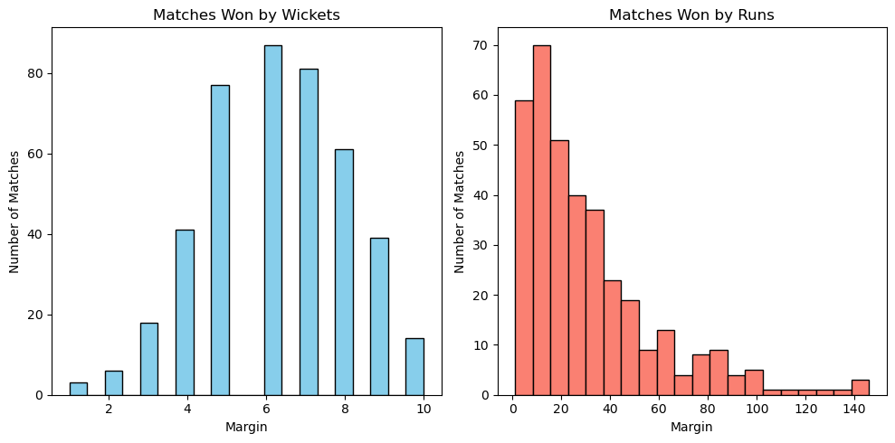

```python
df_wickets = df[df['result'] == 'wickets']


df_runs = df[df['result'] == 'runs']


plt.figure(figsize = (10,5))
plt.subplot(1,2,1)
plt.hist(df_wickets['result_margin'], bins=20, color='skyblue', edgecolor='black')
plt.title("Matches Won by Wickets")
plt.xlabel('Margin')
plt.ylabel('Number of Matches')


plt.subplot(1,2,2)
plt.hist(df_runs['result_margin'], bins=20, color='salmon', edgecolor='black')
plt.title("Matches Won by Runs")
plt.xlabel('Margin')
plt.ylabel('Number of Matches')


plt.tight_layout()
plt.show()
```

# 7) Specific Team Analysis at Top 10 Venues Where they have Played Most of their matches

Here I have taken the team which I like the most (Royal Challengers Bangalore). We are replacing M Chinnaswamy Stadium with its own name as it has repeated 2 times since we are taking 2 columns of data one for team 1 and another for team 2. We are then calculating their performance at the top 10 venues where they have played most of their matches. We then calculate the number of wins and losses at each venue along with the total number of matches played. From the Stacked bar graph, we can see that the whole bar represents the total number of matches played at each venue and green color bar represents the total number of wins at that venue and red color bar represents the total number of losses at those venues. They have played most of their matches at M Chinnaswamy Stadium as this is their home ground. In terms of performance, they have performed very well at Feroz shah Kotla where they have more wins than losses. Their performance at Rajiv Gandhi International Stadium, Uppal and MA Chidambaram stadium, Chepauk where they have more losses than wins.

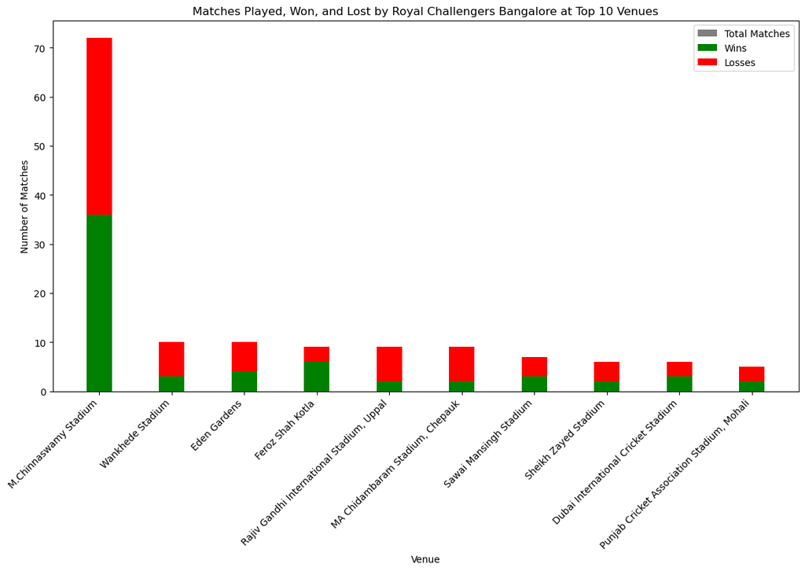

```python
My_favourite_team = 'Royal Challengers Bangalore'
RCB_matches = df[(df['team1'] == My_favourite_team) | (df['team2'] == My_favourite_team)].copy()
RCB_matches['venue'] = RCB_matches['venue'].replace({'M Chinnaswamy Stadium': 'M.Chinnaswamy Stadium'})
venue_Total_matches = RCB_matches['venue'].value_counts()
top_10_venues = venue_Total_matches.head(10)

# Counting wins and losses at each venue
RCB_wins = df[df['winner'] == My_favourite_team]
RCB_wins['venue'] = RCB_wins['venue'].replace({'M Chinnaswamy Stadium': 'M.Chinnaswamy Stadium'})
venue_wins = RCB_wins['venue'].value_counts()

RCB_losses = RCB_matches[RCB_matches['winner'] != My_favourite_team]
venue_losses = RCB_losses['venue'].value_counts()


plt.figure(figsize=(14, 7))

#https://stackoverflow.com/questions/65986403/using-range-and-length-function-together-in-python
index = range(len(top_10_venues))

#https://www.tutorialkart.com/matplotlib-tutorial/matplotlib-pyplot-stacked-bar-plot/#gsc.tab=0
plt.bar(index, venue_Total_matches.loc[top_10_venues.index], bar_width, label='Total Matches', color='black', alpha=0.5)
plt.bar(index, venue_wins.loc[top_10_venues.index], bar_width, label='Wins', color='green')
plt.bar(index, venue_losses.loc[top_10_venues.index], bar_width, label='Losses', color='red', bottom=venue_wins.loc[top_10_venues.index])

#plotting Stacked Bar Chart
plt.xlabel('Venue')
plt.ylabel('Number of Matches')
plt.title('Matches Played, Won, and Lost by Royal Challengers Bangalore at Top 10 Venues')
plt.xticks(index, top_10_venues.index, rotation=45, ha='right')
plt.legend()

plt.show()
```

# Conclusion:

To conclude, we have found that the players with the most player of match are “AB de Villiers” and “CH Gayle”. The most used Venue is “Eden Gardens”. Toss decision by teams - Kolkata Knight Riders prefer to field most of the times if they win the toss and Chennai Super Kings prefer to bat most of the times if they win the toss. The most number of matches were played in the year 2012 and 2013 and there was a sudden drop in the number of matches played in the year 2014. Most of the matches are played in the months of April and May. Distribution of matches peaked on Saturday and Sunday. Match won by wickets is more than more than match won by runs. Royal Challengers Bangalore have played most of their matches at M Chinnaswamy Stadium as this is their home ground. In terms of performance, they have performed very well at Feroz shah Kotla where they have more wins than losses. Their performance at Rajiv Gandhi International Stadium, Uppal, and MA Chidambaram stadium, Chepauk where they have more losses than wins.

# https://youtu.be/obJZ1rB7TKc?si=WpSqP9q5H_6aIa-T

# https://stackoverflow.com/questions/332289/how-do-i-change-the-size-of-figures-drawn-with-matplotlib (for figsize)

# https://www.geeksforgeeks.org/bar-plot-in-matplotlib/ (for bar graph plotting)

# https://www.geeksforgeeks.org/countplot-using-seaborn-in-python/

# https://stackoverflow.com/questions/23627782/pandas-groupby-size-and-percentages

# https://stackoverflow.com/questions/67112449/bar-labels-in-matplotlib-seaborn

# https://seaborn.pydata.org/generated/seaborn.lineplot.html

# https://stackoverflow.com/questions/65986403/using-range-and-length-function-together-in-python

# https://www.tutorialkart.com/matplotlib-tutorial/matplotlib-pyplot-stacked-bar-plot/#gsc.tab=0